# Act report

This report documents all of the EDA efforts done into the project starting by asking questions and using code to answer them in detail followed by Visuals using Python's `matplotlib`, and `seaborn`.

## Analysis & Visualization 📊

After making a new dataset, a new cleaned dataset, I needed to read data from the new **CSV** file and use it in data analysis,  
I had many questions about the dataset and I needed to answer them using code and plots.

### **What is the distribution of retweet counts and favorite counts in the dataset?**

I needed to look into the distribution of the `retweet_count` and `favorite_count`, this columns will help us detect the outliers because if there's we need to be careful in the analysis, A skewness in the data could lead to certain measures.

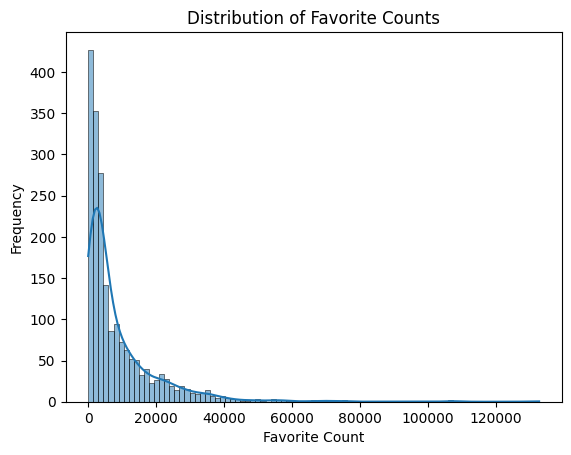

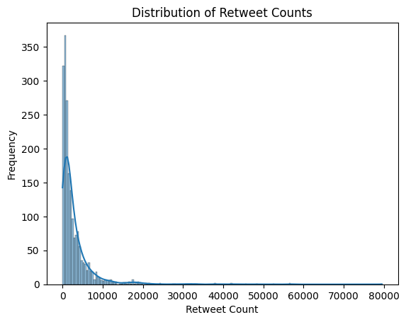

Overall, the distribution of favorite counts highlights the uneven distribution of popularity among tweets, with a small number of posts garnering a significantly higher number of favorites compared to the majority.

- **How do retweet counts and favorite counts vary across tweets?**

  We can look into the tweets and find how they vary, does it depend on a certain factor, or maybe two, or maybe more, We need to look into the distribution of the column and then look into the coorelations between them.

  To see how retweet counts and favorite counts vary across tweets, I can use a scatter plot.

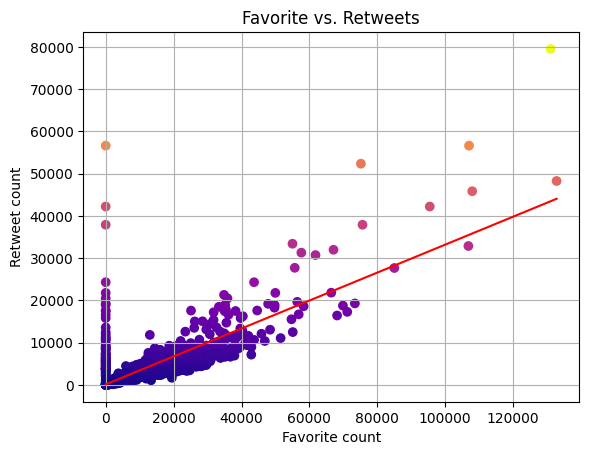

the scatter plot reveals a positive relationship between favorite counts and retweet counts, but the presence of outliers and the non-linear pattern suggest that a more complex analysis might be needed to fully understand the factors driving this relationship.

- **Are there any outliers in the retweet and favorite counts, and what is their impact?**

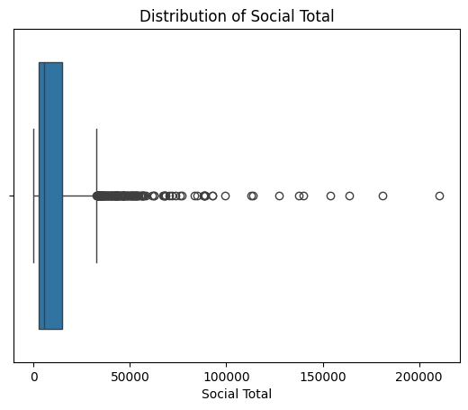

Yes, there are significant outliers in the data as indicated by the individual data points plotted beyond the whiskers of the box plot. These outliers represent a small number of data points with exceptionally high social total values compared to the majority of the data.

the presence of outliers in the social total data suggests that further investigation is needed to understand their impact on the analysis and to draw meaningful conclusions about the distribution of social totals.

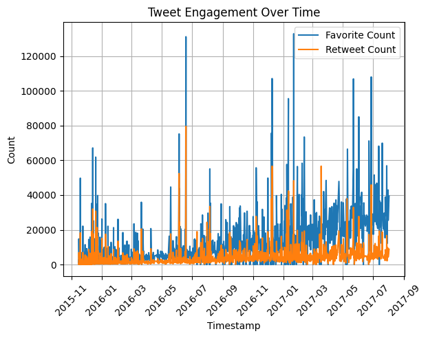

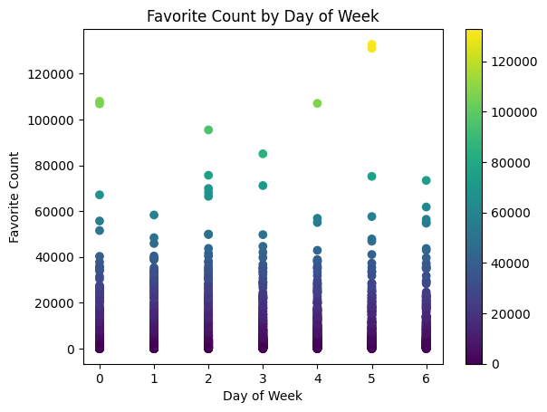

```python
correlation = df_2['day_of_week'].corr(df_2['favorite_count'])
correlation
```

```
-0.00494435705996501
```

- A correlation of `-0.0049...` between the day of the week and favorite count suggests that there's a very weak negative correlation between these two variables. However, the correlation is so close to zero that it's practically negligible.
- This means that the day of the week doesn't have a significant impact on the number of favorites a tweet receives. The number of favorites a tweet gets is likely influenced by other factors more strongly than the day of the week it was posted.

### **What is the distribution of ratings given to the tweets?**

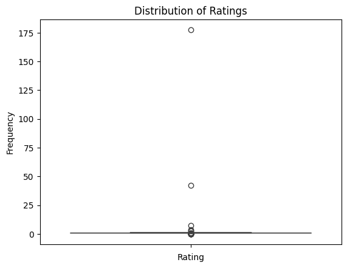

The distribution of ratings is highly skewed to the right. This indicates that a large majority of tweets received a very low number of ratings, while a small number of tweets received an exceptionally high number of ratings.

Overall, the distribution of ratings indicates a high degree of variability with a concentration of low ratings and a few extremely high ratings.

- **Are there any extreme values or outliers in the ratings?**

  Yes, from the boxplot above, We can obviously see the outliers and We remove them to investgate the even further through the analysis.

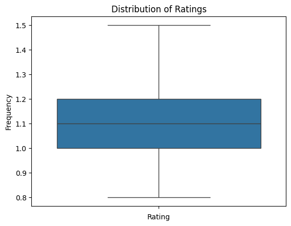

- **How do ratings vary across different dog breeds?**

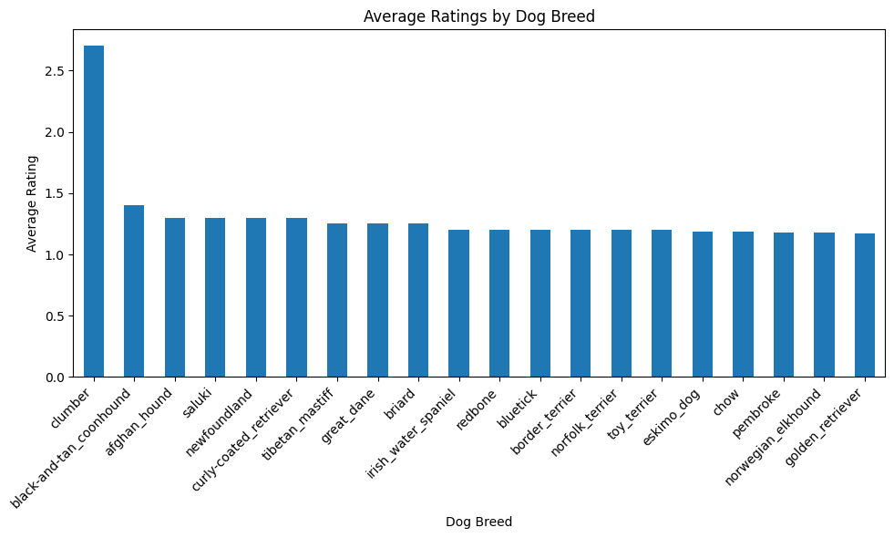

- **How have the ratings changed over time?**

  To analyze how ratings have changed over time, you can plot the average rating for each time period.

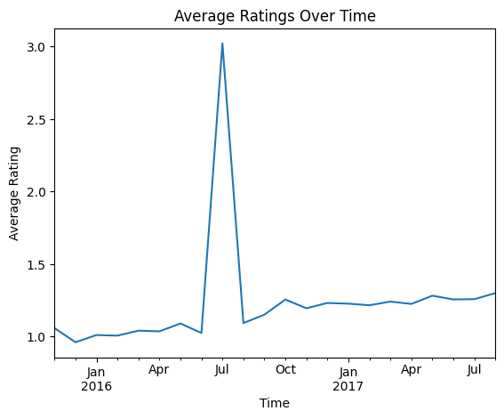

There was a notable peak in ratings around July 2016, followed by a sharp decline. Subsequently, the ratings stabilized at a lower level with minor fluctuations throughout 2017.

### **How frequently do different dog stages and breeds appear in the tweets?**

To visualize the frequency of different dog stages and breeds, We can use bar plots.

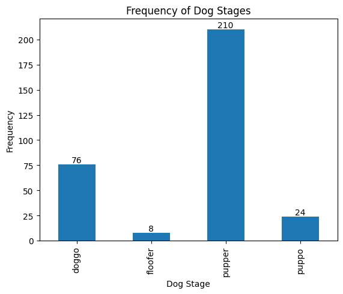

- **Which dog stages and breeds are the most popular based on engagement metrics?**

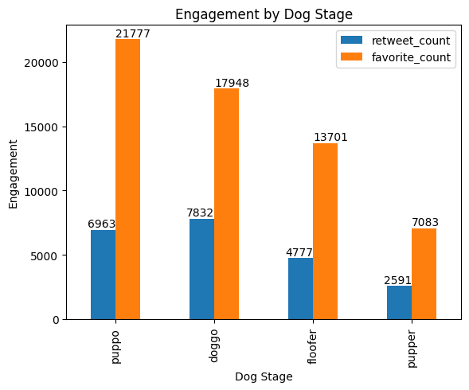

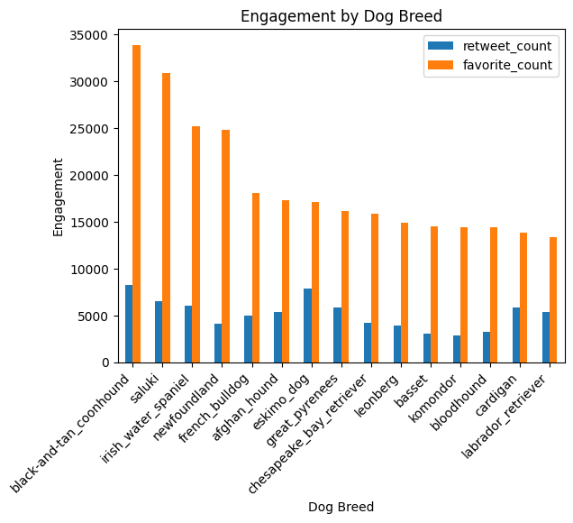

[figure not shown]

[figure not shown]

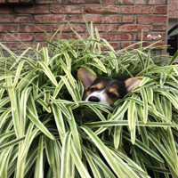

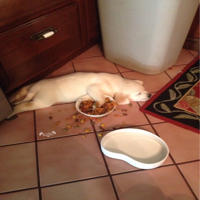

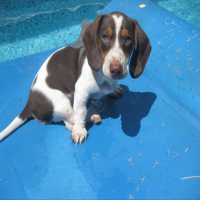

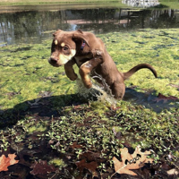

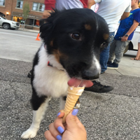

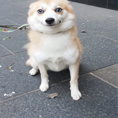

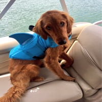

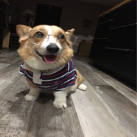

[5 more figures not shown]

### **How does tweet engagement change over time?**

To proceed with analyzing how tweet engagement changes over time, we'll break down the steps and code to visualize the trends:

1. Convert the timestamp to a datetime format.
2. Extract year and month from the timestamp.
3. Group by year and month to calculate average engagement metrics.
4. Plot the trends over time.

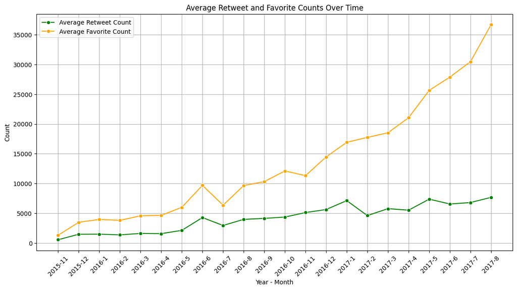

### **What are the common themes and sentiments in the tweet content?**

1. Word Frequency Analysis
- Clean and preprocess the text data (remove stop words, punctuation, etc.).
- Generate a word cloud or frequency distribution of the most common words.
2. Sentiment Analysis
- Use a sentiment analysis tool or library (e.g., TextBlob, VADER) to analyze the sentiment of each tweet.
- Classify the sentiment as positive, negative, or neutral. Analyze the distribution of sentiments and their relationship with engagement metrics.

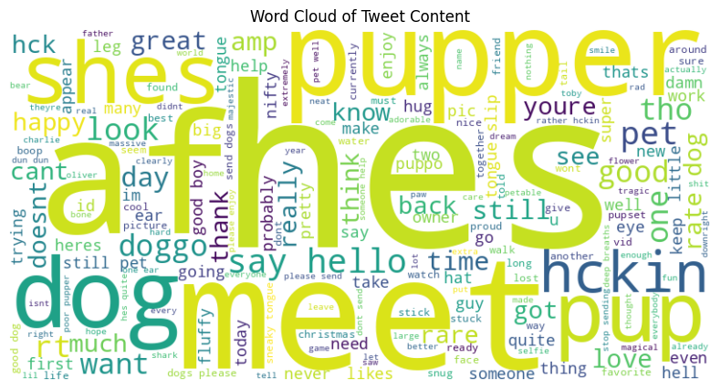

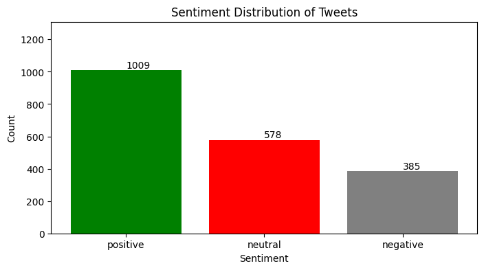

### **Conclusion**

- The WeRateDogs Twitter account experienced significant growth in user engagement from late 2015 to mid-2017. The increasing trends in both favorite and retweet counts reflect the rising popularity of the account. Peaks in the data indicate periods of particularly high engagement, possibly due to viral content or notable events. The consistently higher favorite counts compared to retweet counts align with typical Twitter user behavior.